# Experiment 2 — Longer matched history

**Finding:** The longer history still does not consistently beat persistence for operating performance. Cash-cover gains are mixed; maintenance beats persistence more often, but the training mean has lower pooled MAE.

This short notebook reads saved, verified results and redraws the main comparison. It does not refit models. The complete fitting code is in run_experiment.py.

## 1. Design

**Fiscal t−1 + disaster t → fiscal outcome t+1.** Train on earlier complete financial years, keeping the original one-year gap. Imputation is fitted within training folds; outcomes are never imputed. Operating performance is primary; cash cover and maintenance are separate secondary outcomes.

103 continuing councils; V2 fiscal and disaster panels. Persistence, training mean, ridge and a depth-3 tree. Ridge uses inner forward-year validation; unknown declarations remain explicit categories.

MAE and RMSE measure error (lower is better); R² compares squared errors with the held-out mean and may be negative. Results are retrospective, not causal or proof of real-time forecast availability.

```python
from pathlib import Path
import pandas as pd
import matplotlib.pyplot as plt

root = next(p for p in [Path.cwd(), *Path.cwd().parents] if (p / 'NSW Data Panel.csv').exists())
folder = root / 'Experiment 2'
results = folder / 'results'
plt.rcParams.update({'figure.figsize': (8, 4), 'font.size': 11})
```

## 2. Primary results

Operating-performance errors are in **percentage points**. All models within each experiment use identical held-out rows. The two experiments have different cohorts and years; their pooled scores are not a controlled before/after comparison.

```python
summary = pd.read_csv(results / 'pooled_and_equal_year_summary.csv')
summary = summary[summary.history.eq('long')]
annual = pd.read_csv(results / 'year_by_year_metrics.csv')
annual = annual[annual.history.eq('long')]
primary = summary[summary.target.eq('operating_ratio_pct') & summary.spec.isin(['baseline', 'fiscal_only', 'fiscal_plus_disaster'])]
primary[['spec', 'model', 'n', 'MAE', 'RMSE', 'R2', 'both_years_won', 'folds']].round(3)
```

|  | spec | model | n | MAE | RMSE | R2 | both_years_won | folds |
| --- | --- | --- | --- | --- | --- | --- | --- | --- |
| 32 | baseline | persistence | 818 | 7.334 | 9.848 | -0.050 | 0 | 8 |
| 33 | baseline | training_mean | 818 | 7.409 | 10.123 | -0.109 | 2 | 8 |
| 34 | fiscal_only | ridge | 818 | 7.690 | 10.167 | -0.119 | 4 | 8 |
| 35 | fiscal_only | tree | 818 | 7.921 | 10.418 | -0.175 | 1 | 8 |
| 36 | fiscal_plus_disaster | ridge | 818 | 7.393 | 9.761 | -0.031 | 1 | 8 |
| 37 | fiscal_plus_disaster | tree | 818 | 7.764 | 10.331 | -0.155 | 2 | 8 |

## 3. Does performance transfer across years?

Every evaluated primary-target year is shown. Lower lines indicate smaller errors; a pooled improvement alone does not establish a consistent win. Ridge and tree lines here use fiscal plus disaster predictors.

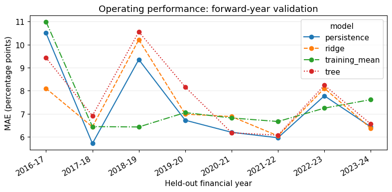

```python
yearly = annual[annual.target.eq('operating_ratio_pct')].copy()
yearly = yearly[yearly.spec.isin(['baseline', 'fiscal_plus_disaster'])]
errors = yearly.pivot(index='test_fy', columns='model', values='MAE')
ax = errors.plot(marker='o', style=['-', '--', '-.', ':'][:len(errors.columns)])
ax.set(title='Operating performance: forward-year validation', xlabel='Held-out financial year', ylabel='MAE (percentage points)')
ax.grid(axis='y', alpha=0.25)
plt.xticks(rotation=30, ha='right')
plt.tight_layout()
plt.show()
```

## 4. Secondary outcomes and disaster contribution

Cash cover is measured in months; maintenance in percentage points. Compare errors only within each target. The fiscal-only versus fiscal-plus-disaster rows in the primary table show the ablation.

```python
secondary = summary[~summary.target.eq('operating_ratio_pct') & summary.spec.isin(['baseline', 'fiscal_plus_disaster'])]
secondary[['target', 'model', 'MAE', 'RMSE', 'R2', 'both_years_won', 'folds']].round(3)
```

|  | target | model | MAE | RMSE | R2 | both_years_won | folds |
| --- | --- | --- | --- | --- | --- | --- | --- |
| 0 | cash_cover_months | persistence | 3.346 | 4.681 | 0.549 | 0 | 7 |
| 1 | cash_cover_months | training_mean | 5.244 | 7.067 | -0.028 | 0 | 7 |
| 4 | cash_cover_months | ridge | 3.493 | 4.729 | 0.540 | 4 | 7 |
| 5 | cash_cover_months | tree | 3.527 | 4.985 | 0.488 | 1 | 7 |
| 16 | maintenance_ratio_pct | persistence | 21.894 | 43.023 | -0.532 | 0 | 9 |
| 17 | maintenance_ratio_pct | training_mean | 19.520 | 34.828 | -0.004 | 7 | 9 |
| 20 | maintenance_ratio_pct | ridge | 20.233 | 36.377 | -0.095 | 6 | 9 |
| 21 | maintenance_ratio_pct | tree | 19.845 | 34.327 | 0.025 | 7 | 9 |

**Interpretation:** Cash cover has no consistent benchmark win. Maintenance trees beat persistence on both errors in 7/9 years, but the training mean has lower pooled MAE. Across all V2 trees, the only disaster-related split is the bushfire declaration **unknown** indicator—not mapped burned area or known disaster presence. This is reporting coverage, not evidence of a disaster effect.

## 5. Conclusion and reproduction

**NO-GO for escalating model complexity on this evidence.** Few independent years, repeated councils, changing measurement and unknown exposure limit what can be concluded. This does not prove council finances are inherently unpredictable.

Full results and limitations · All annual metrics

To deliberately refit the original specification, run from AUSSEF:

```
python "Experiment 2/run_experiment.py"
```

The short notebook only reads those outputs. Historical notebooks are archived under `support/`; input construction audits retain historical source paths documented in the project README.